# Brownlows Bets

Jason Rivera

October 16th, 2019

### 0.0.1 2019-11-23

# 1 Introduction

At the first day of class there are 35 students in Math Statistics class and professor Brownlow always proposes this bet to his students “I will wager $2 to your bet of $1 that at least two people in today’s class have the same birthday. He tells me he has made that bet 1137 times so far. Where do you think his profits are? Discuss this in a markdown document

# 2 Methods

# 3 Profit Estimate

First we create the year data and a vector to contain samples

```r
Bdays = 1:365
Bsamples = vector('numeric')
TotalDollars = 0
saveDollars=vector('numeric')
```

run the simulation 1137 times.

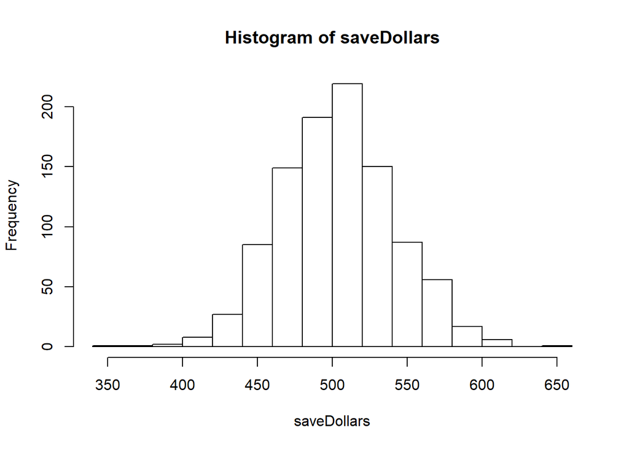

```r
for(loop in 1:1000){


TotalDollars=0
classSize = 35
for(i in 1:1137) {
Bsamples = sample(Bdays,classSize, replace=TRUE)
if (length(unique(Bsamples)) == classSize) {
  TotalDollars = TotalDollars -2
} else{
  TotalDollars = TotalDollars +1
}
}

saveDollars[loop] = TotalDollars
}

hist(saveDollars)
```

```r
print(mean(saveDollars))
```

```
## [1] 504.042
```

# 4 Confidence interval of Brownlow’s earning

```r
stdevDollars = sd(saveDollars)
meanDollars= mean(saveDollars)
CI = c(meanDollars-2*stdevDollars, meanDollars+2*stdevDollars)

print(CI)
```

```
## [1] 426.9802 581.1038
```

95% of the time Brownlow will make between $430 and $580

# 5 Discussion and Conclusion

If he has 35 students his payout to break even must be $4.50 to $1.00. There would have to be 28 or 29 students in the class for Brownlow to break even.